# Calculus answers

RobHayward

6 December 2015

Answers

1. $y = 2 + 6x$

$\frac{d(y)}{d(x)} = 6$

2. $y = 5 - 4x +2x^3$

$\frac{d(y)}{d(x)} = -4 + 6x^2$

3. $y = 25 +6x^2 - 3x^3 +25x^4$

$\frac{d(y)}{d(x)} = 12x - 9x^2 + 100x^3$

4. $y - 3 = 2x$

$\frac{d(y)}{d(x)} = 2$

5. $TPP = 24 +5L +2L^2 - L^3$

$\frac{d(TPP)}{d(L)} = 5 +4L - 3L^2$

Find the second derivative of the following

6. $TU = 25 + X_1 - X_1^2$

$\frac{dy}{dx} = 1 - 2X_1$

$\frac{d^2(U)}{d(X_1)} = -2$

7. $TU = 25 +25X_1 -2X_1^2$

$\frac{dy}{dx} = 25 - 4X_1$

$\frac{d^2(U)}{d(X_1)} = - 4$

There is diminishing marginal utility. The first derivative is the slope of the utility relative to the consumption of product $X_1$. This is marginl utility. The second derivative shows how the slope or marginal utility changes with $X_1$. The result is -2 or -4. Therefore, the slope is falling as the consumption of $X_1$ increases. This is *diminishing marginal utility*.

8. $TPP = 15 +15Q +Q^2 - Q^3$

$\frac{TPP}{dQ} = 15 + 2Q - 3Q^2$

$\frac{d^2(TPP)}{d(Q)} = 2 -6Q$

9. What does your answer to the previous question tell you about the shape of the Total Physical Product Curve?

17. Given a demand curve

$Q_d = 90 - 5P + 0.2P^2$

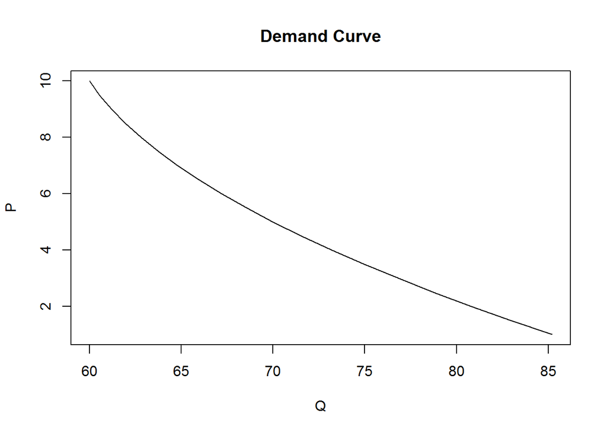

What is the elasticity of demand at the point $P = 5, Q = 70$?

The equation for elasticity is

$\varepsilon_d = \frac{d(Q)}{d(P)}\times \frac{P}{Q}$

$\frac{dQ}{dP} = -5 + 0.4P$

As the absolute value is below one, the demand is inelastic

10. Here is the total physical product curve. Show the *average physical product* and the *marginal physical product* at the point where 8 units of labour are being used.

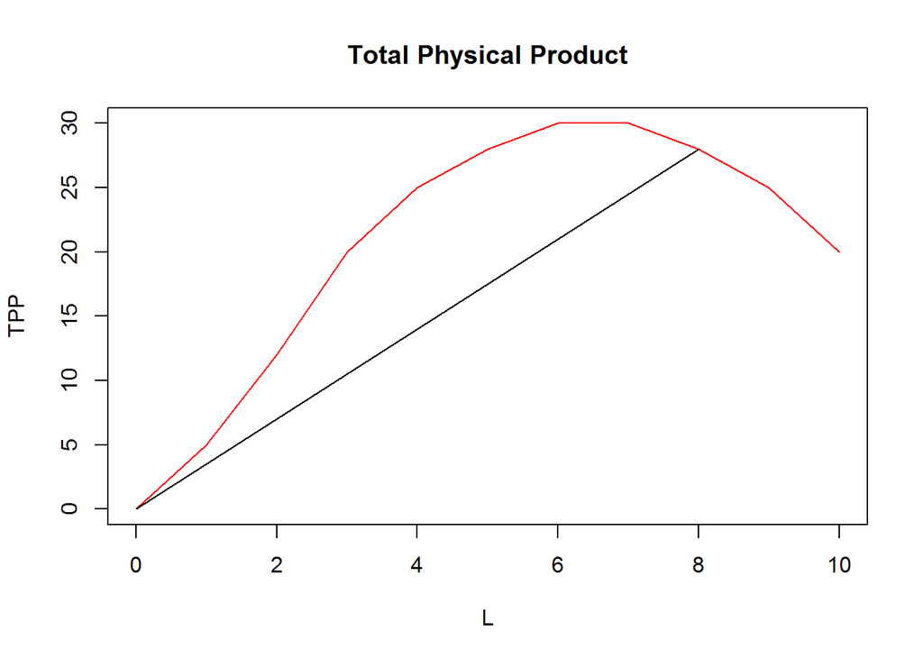

14. Given the $TPP = 500 + 180Q + 15Q^2 - 2Q^3$,

MPP is the *marginal physical product* or the slope of the *total physical product*

The gradient of the TPP is zero at its peak.

This cannot be solved by factorising. You will have to use the equation

$x = \frac{-b \pm \sqrt{b^2 - 4ac}}{2a}$

Input this into your calculator or click the following link.

[On line quadratic solver](http://www.math.com/students/calculators/source/quadratic.htm)

Remember that, a, b and c are given by the equation

$ax^2 + bx + c$

14. Given the $TPP = 100 + 32Q +23Q^2 - Q^3$,

Find the MPP

$MPP = 32 + 46Q - 3Q^2$

Set MPP equal to zero

$3Q^2 - 46Q -32 = 0$ $(3Q + 2)(Q - 16) = 0$

Therefore $3Q = -2 \quad \text{or} \quad Q = 16$

$Q = 16$ at the maximum.